# R for Beginners

Jeho Park  
Feb 1, 2017

HMC Scientific Computing Workshop Series, Spring 2017

https://github.com/jehopark/r-workshop-for-beginners-sp2017.git

### Some Housekeeping Stuff

- **Slides** at http://bit.ly/hmc-r-workshop-slides-sp2017
- **R files** at http://bit.ly/hmc-r-workshop-github-sp2017
- **Sign-in** at http://bit.ly/hmc-r-workshop-sign-in
- **Digital badge requirements**
  - Attend the workshop (Sign-in above)
  - Your work in RStudio (R file submission)

### Workshop Agenda: Real Basics of R

- What is R?
- What is not R?
- Then Why R?
- What is RStudio?
- What can you do with it? (some math example)

### Workshop Agenda: Basics of R

- Demos, search, and help documents
- Workspace of R
- R Objects: Vector, Matrix, List, Data Frame, Factor, Function
- Converting between different types
- Working with Data: Import/Export, subsetting

### What is R?

- R is a statical programming language/environment.
- R is open source/free.
- R is widely used/prefered.
- R is cross-platform.
- R is hard to learn (really?).

### What is not R?

- S: R's ancestor
- S-Plus: Commercial; modern implementation of S
- SAS: Commercial; widely used in the commercial analytics.
- SPSS: Commercial; easy to use; widely used in Social Science.
- MATLAB: Commercial; can do some Stats.
- Python: Also can do some Stats; good in text data manipulation.

### Then Why R?

- **R community is active and constantly growing**
- R is one of the most popular stat programming lang
- R has tons of user generated libraries/packages
- R code is easily shared with others
- R is constantly improved

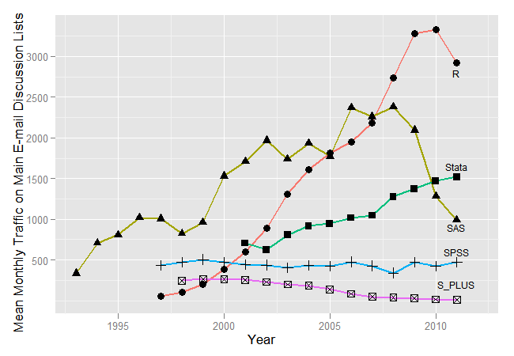

### Then Why R?

- R community is active and constantly growing
- **R is one of the most popular stat programming lang**
- R has tons of user generated libraries/packages
- R code is easily shared with others
- R is constantly improving

###### Further reading about R's popularity in science and engineering:

###### R moves up to 5th place in IEEE language rankings at https://www.r-bloggers.com/r-moves-up-to-5th-place-in-ieee-language-rankings/

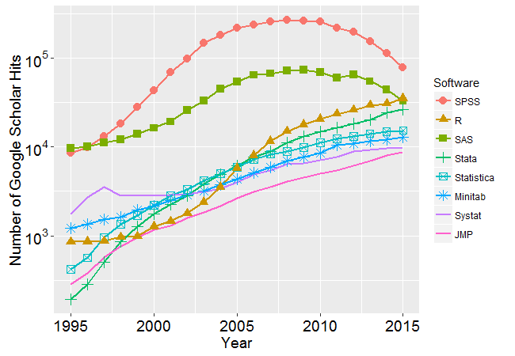

### Then Why R?

- R community is active and constantly growing
- R is one of the most popular stat programming lang)
- **R has tons of user generated libraries/packages**
- R code is easily shared with others
- R is constantly improved

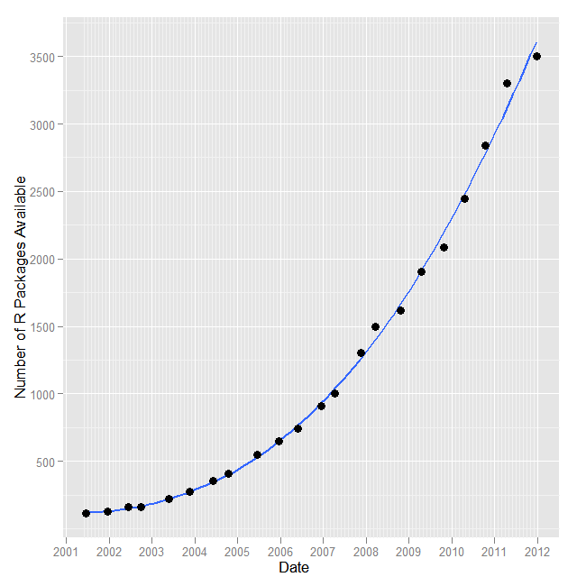

### Getting help online and offline

- Rseek meta search engine: http://rseek.org/
- R-help listserv: https://www.r-project.org/mail.html
- Stack Overflow: http://stackoverflow.com/questions/tagged/r
- Cross-Validated: the statistics Q&A site http://stats.stackexchange.com/
- Contact CIS: helpdesk@hmc.edu or jepark@hmc.edu
- HMC R Users Group: r-users-l@g.hmc.edu

### Some R Vocabulary

- **packages** are add on features to R that include data, new functions and methods, and extended capabilities. Think of them as “apps'' on your phone. We've already installed several!
- **console** is the main window of R where you enter commands
- **scripts** are where you store commands to be run in the terminal later, like syntax files in SPSS or .do files in Stata
- **functions** are commands that do something to an object in R
- **workspace** is the working memory of R where all objects are stored
- **vector** is the basic unit of data in R
- **dataframe** is the main element for statistical purposes, an object with rows and columns that includes numbers, factors, and other data types

### What is RStudio?

- Integrated Development Environment for R
- Nice combination of GUI and CLI
- Free and commercial version
- 4 main windows, tabs, etc
- Version control: Git and VPN
- R Markdown
- R Presentation

### Get ready

- Open RStudio!

### What Can We Do with RStudio?

[figure not shown]

### Look Ma, R can do Math!

```r
1+1
```

```r
2+runif(1,0,1)
```

```r
2+runif(1,min=0,max=1)
```

```r
3^2
```

```r
3*3
```

```r
sqrt(3*3) # comments
```

```r
# comments are preceded by hash sign
```

### Even More Math!

- R can take integrals and derivatives, for example:

Numerical Integral of

\( \displaystyle\int_0^{\infty} \frac{1}{(x+1)\sqrt{x}}dx \)

```r
integrand <- function(x) {1/((x+1)*sqrt(x))} ## define the function
```

```r
integrate(integrand, lower=0, upper=Inf) ## integrate the function from 0 to infinity
```

```
3.141593 with absolute error < 2.7e-05
```

### Some General Stuff

```r
demo() # display available demos
```

```r
demo(graphics) # try graphics demo
```

```r
library() # show available packages on the computer
```

```r
search() # show loaded packages
```

```r
?hist # search for the usage of hist function
```

```r
??histogram # search for package documents containing the word "histogram"
```

### Workspace of R

R workspace stores objects like vecors, datasets and functions in memory (the available space for calculation is limited to the size of the RAM).

```r
a <- 5 # notice a in your Environment window
```

```r
A <- "text"
```

```r
a
A
ls()
print(c(a,A))
print(a,A)
```

### R as a Programming Language: R Objects

**VECTOR** (homogeneous)  
A vector is an array object of the same type data elements.

```r
class(a)
```

```r
class(A)
```

```r
B <- c(a,A) # concatenation
```

```r
print(B)
```

```r
class(B) # why?
```

### R Objects: Vectors (cont.)

R has five basic or “atomic” classes of objects:

- character
- numeric (real numbers)
- integer
- complex
- logical (True/False)

A vector contains a set of data in any one of the atomic classes.

### R as a Programming Language: R Objects

**Matrices** (homogeneous)  
A matrix is a two-dimensional rectangular object of the **same type** (homogeneous) data elements.

```r
mat <- matrix(rnorm(6), nrow = 3, ncol = 2)
mat # a matrix
dim(mat) # dimension
t(mat)
summary(mat)
```

### R as a Programming Language: R Objects

**LIST** (heterogeneous)  
A list is an object that can store different types of vectors.

```r
aList <- list(name=c("Joseph"), married=T, kids=2)
aList
aList$kids <- aList$kids+1
aList$kids
aList2 <- list(numeric_data=a,character_data=A)
aList2
allList <- list(aList, aList2)
allList # a list of lists
```

### R as a Programming Language: R Objects

**Data Frame** (heterogeneous and homogeneous)  
A data frame is used for storing data tables. It is a list of vectors of equal length.

```r
n <- c(2, 3, 5) # a vector
s <- c("aa", "bb", "cc") # a vector
b <- c(TRUE, FALSE, TRUE) # a vector
df <- data.frame(n, s, b) # a data frame
df
mtcars # a built-in (attached) data frame
mtcars$mpg
```

### R as a Programming Language: R Objects

**Data Frame** (cont.)

```r
myFrame <- data.frame(y1=rnorm(100),y2=rnorm(100), y3=rnorm(100))
head(myFrame) # display first few lines of data
names(myFrame) # display column names
summary(myFrame) # output depends on the data types
plot(myFrame)
myFrame2 <- read.table(file="http://scicomp.hmc.edu/data/R/Rtest.txt", header=T, sep=",")
myFrame2
```

### R as a Programming Language: R Objects

**FACTOR**

- Factors are a special compoud object used to represent categorical data such as gender, social class, etc.
- Factors have 'levels' attribute. They may be nominal or ordered.

```r
v <- c("a","b","c","c","b")
x <- factor(v) # turn the character vector into a factor object
z <- factor(v, ordered = TRUE) # ordered factor
x
z
table(x)
```

### R as a Programming Language: R Objects

**Function**  
Functions are also objects in R environment

```r
fun <- function(a,b) {
  a*b
}

fun
fun(2,3) # a function call
```

### Converting between different types

Use of the as() family of functions. Type as. and wait to see the list of as() functions.

```r
integers <- 1:10
as.character(integers)
as.numeric(c('3.7', '4.8'))
```

```r
indices <- c(1.7, 2.3)
integers[indices] # sometimes R is too generous
integers[0.999999999] # close to 1 but...
```

```r
df <- as.data.frame(mat)
df
```

### Working with Data

- Working with raw data (text files)
- Data import and export
- Subsetting
- Using data frames vs. matrices

### Working with Raw Data (text files)

- Use read.table() to read text files into R
- Try help document for read.table()

### Data Import

- read.csv() is a special case of read.table()
- Data import from your local folder

```r
cpds <- read.csv(file.path('.', 'data', 'cpds.csv'))
head(cpds) # good to look at a few lines
class(cpds) # data.frame
```

- Data import from the Internet

```r
data <- read.table(file="http://scicomp.hmc.edu/data/R/normtemp.txt", header=T)
tail(data)
```

### Data Import (Cont.)

```r
rta <- read.table("./data/RTADataSub.csv", sep = ",", head = TRUE)
dim(rta)
rta[1:5, 1:5]
class(rta)
class(rta$time) # what? let's see ?read.table more carefully
```

```r
rta2 <- read.table("./data/RTADataSub.csv", sep = ",", head = TRUE, stringsAsFactors = FALSE)
class(rta2$time)
```

### Data Export

- Use write.table() to write data to a CSV file

```r
write.csv(data, file = "temp.csv", row.names = FALSE)
```

- Save all the objects in current environmet

```r
save.image(file="myenv.RData")
# Q: How to load them back later?
```

### Subsseting

Operators that can be used to extract subsets of R objects.

- '[' and ']' always returns an object of the same class as the original; can be used to select more than one element.
- '[[' and ']]' is used to extract elements of a list or a data frame; it can only be used to extract a single element.
- $ is used to extract elements of a list or data frame by name.

### Subsetting (cont.)

```r
x <- c("a", "b", "c", "c", "d", "a")
x[1]
x[1:4]
x[x > "a"]
u <- x > "a" # what's u here?
u
x[u] # subsetting using a boolean vector
y <- list(foo=x, bar=x[u])
y
y[[1]]
y$bar
```

```r
subset(mtcars, gear == 5) # use of subset function for data frames
```

### Data frame vs matrix

Consider the following:

- Same types or different types? Numeric or other type?
- Convenient using $ with col names?
- Data size too big? (memory efficiency and size)

```r
m = matrix(1:400000, 2, 200000) # esp. for a large number of columns!
d = as.data.frame(m)
object.size(m) # 1600200 bytes
object.size(d) # 22400568 bytes
```

- Conversion between data frame and matrix
  - as.data.frame()
  - as.matrix() or data.matrix() # consider coercion

### That's it!

Please submit your R environemnt file* at http://bit.ly/hmc-r-workshop-sign-in (digital badge requirement).

*You should know how to export the objetcs in your environment to a Rdata file.

**Further Study!**

- Online learning resources: https://www.rstudio.com/online-learning/#R
- Swirl (self-paced interactive learning) package: http://swirlstats.com/